```python
import numpy as np
import matplotlib
import matplotlib.pyplot as plt
import scipy
import pandas as pd
from scipy import stats

#this sets the size of the plot to something useful
plt.rcParams["figure.figsize"] = (12,7.5)
plt.rcParams["xtick.labelsize"] = 18
plt.rcParams["ytick.labelsize"] = 18
```

# Lab #3: Asking a statistical question

This week we are going to concentrate on asking a statistical question. This process almost always consists of 3+ steps:

1. Writing down in words very precisely what question you are trying to ask.
2. Translating the precise english question into a mathematical expression. This often includes determining the pdf of the background (possibly including trials), and the to integral to do to obtain a probability.
3. Coverting the probability into equivalent sigma

So in this lab we will assume that we know the form of the signal-free background distribution (determining a distribution from data will be next week's lab). In each of our three examples, your task will be to state the statistical question, convert it to math, then perform the associated analyses.

## Problem 1

In our first example we are looking at the temperature reading (meta-data) associated with an experiment. For the experiment to work reliably, the temperature should be at around 12 Kelvin, and if we look at the data it is mostly consistent with 12 Kelvin to within the 0.4 degree precision of the thermometry and the thermal control system (standard deviation). However, there are times when the thermal control system misbehaved and the temperature was not near 12 K, and in addition there are various glitches in the thermometry that give anomalously high and low readings (the reading does not match the real temperature). We definitely want to identify and throw out all the data when the thermal control system was not working (and the temperature was truly off from nominal). While it is possible to have an error in the thermometry such that the true temperature was fine, and we just had a wonky reading, in an abundance of caution we want to throw those values out too.

To make this a bit concrete, we will simulate a little data. Start by simulating 100k 'good' data points assuming Gaussian fluctations, and because we are playing god adding the following 'bad' datapoints: {10., 10.3, 2.1, 0., 0., 15.6, 22.3, 12.7}

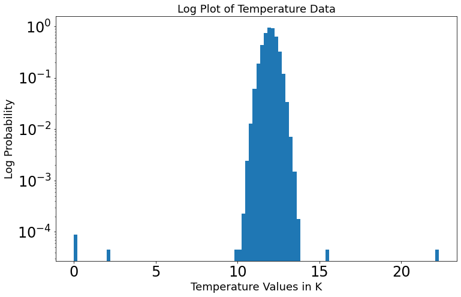

```python
d = np.append(stats.norm.rvs(loc = 12., scale = 0.4, size = 100000), [10., 10.3, 2.1, 0., 0., 15.6, 22.3, 12.7])
fig, ax = plt.subplots(1, 1)
ax.hist(d,100, density=True)
plt.tick_params(labelsize = 24)
plt.title("Log Plot of Temperature Data", fontsize=18)
plt.xlabel("Temperature Values in K", fontsize=18)
plt.ylabel("Log Probability", fontsize=18)
plt.yscale('log')
plt.show()
```

#### A) So our goal is to identify bad data and throw it out.

##### 1. Start by exploring the data you have created with appropriate plots

See plot above

##### 2. State the statistical question in words. Be very clear, and describe why you have chosen this statistical question.

Given this data set, we will categorize bad data as data that lies more than 4 standard deviations outside the mean. How many data points lie outside of this threshold? I chose this statistical question to find a balance between eliminating as much bad data as possible while keeping most of the good data.

##### 3. Restate your question in math. Be very clear.

How many data points lie outside of the threshold of four standard deviations. In other words, how many data points are less than 10.4 and greater than 13.6 K?

##### 4. Apply your statistical test and construct a truth table.

```python
outlier_data = []
mean = 12
std_dev = 0.4
num_dev = 4
for i in d:
    if abs(i-mean) > num_dev*std_dev:
        outlier_data.append(i)
print("Number of bad data points according to the test: " + str(len(bad_data)))
print("Bad Data Points according to the Test:")
print(bad_data)

total_data_points = 100008
test_good_true_T = total_data_points - len(outlier_data) - 1 # data points that the test thought was good and are actually good
test_good_bad_T = 1 # 12.7 is the given bad data point that is within the threshold of the test
test_bad_true_T = 8 # These are the points that fell outside of 4 standard deviations from the "good" random Guassian distribution
test_bad_bad_T = 7 # These are the bad data that were given, that the statistical test caught as being bad

truth_table_data = [[test_good_true_T, test_good_bad_T], [test_bad_true_T, test_bad_bad_T]]
df= pd.DataFrame(truth_table_data, columns=['True T', 'Bad T'], index=['Your Test Good', 'Your Test Bad'])
display(df)
```

[output not shown]

|  | True T | Bad T |
| --- | --- | --- |
| Your Test Good | 99992 | 1 |
| Your Test Bad | 8 | 7 |

#### B) How does the number of omissions, where you threw out good data, depend on the statistical threshold you chose and is it a predictable quantity?

Yes it does depend on the statistical threshold; if you choose a fewer number of standard deviations to be your threshold, you will throw out more good data. In this case, I chose my threshold to be 4 standard deviations away from the mean so I excluded 8 data points that are good (from the Guassian), but were bad according to my test. It is a predictable quantity in this case because the data is a Guassian, so there is a certain probablity that some points will fall outside of 4 standard deviations of the mean in a sample of 100,000 points. In this case on average, my test of 4 standard deviations will categorize about 6 data points out of 100,000 to be bad data points, when these data points are actually good.

```python
print("Probability of data falling outside of 4 standard deviations if the data follows a Gaussian distribution: " + str(stats.norm.cdf(-4)*2))
```

```
Probability of data falling outside of 4 standard deviations if the data follows a Gaussian distribution: 6.334248366623973e-05
```

#### C) Are there mistakes of commission (bad data getting in)? If yes, are they avoidable and how do they depend on your statistical threshold?

Yes, there was one mistake of commission or one instance of bad data getting in. The data point 12.7 falls within four standard deviations of the mean, so my test included this bad data point as a good data point. This can be avoided by further narrowing the statistical threshold, but in this case we would throw out a lot of good data to eliminate this one bad data point (12.7 when the data is Guassian with mean of 12 and standard deviation of 0.4). Perhaps in some cases it can be worth it, in cases where any error is intolerable, but that would depend on the case.

## Problem 2

In this example we will be looking for asteroids. If we look at the alignment of stars on subsequent images, they don't perfectly align due to atmospheric and instrumental effects (even ignoring proper motion). The resulting distribution is two dimensional, and for this lab let's assume it is a 2D Gaussian with 1 arcsecond RMS. Or said another way, if I histogram how far all the (stationary) stars appear to have moved I get something like:

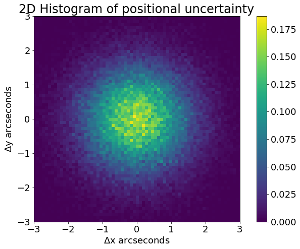

```python
a = np.vstack((stats.norm.rvs( scale = 1, size = 100000), stats.norm.rvs( scale = 1, size = 100000)))
a.shape
fig, ax = plt.subplots(1, 1)
h = ax.hist2d(a[0,:],a[1,:],bins=100, density=True);
ax.set_aspect('equal', 'box')
plt.xlim([-3 , 3])
plt.ylim([-3 , 3])
plt.title("2D Histogram of positional uncertainty", fontsize = 24)
plt.ylabel("$\Delta$y arcseconds", fontsize = 18)
plt.xlabel("$\Delta$x arcseconds", fontsize = 18)
plt.colorbar(h[3], ax=ax)
```

If I have a potential asteroid, it will have some true movement between the images. We would like a '5 sigma' detection of movement. What is that distance in arcseconds?

#### 1. What is the question in words?

If there is no signal, or if there are no asteroids detected in these images, then the background data is how far the stationary stars appear to have moved and this data has a 2D Guassian distribution with a standard deviation of one arcsecond. What is the probability that the data produces a signal greater than 5 sigma, which is our threshold for differentiating true movement of asteroids from the movement generated by instrumental and environmental uncertainty of stationary stars, and what distance in arcseconds does that probability correspond to?

#### 2. What is the question in math? [Hint: Come up with an analytic description of your pdf(). The Blue Book may be helpful here.]

The distance can be described as the amplitude of the vector created by these two 1D Guassian distributions. As we found in HW3, this amplitude vector has a rayleigh distribution. In math, we want to find this pdf, then given the probabilty of 5 sigma, we want to find the area under the rayleigh distribution that corresponds to 5 sigma, then find the value (x) on the rayleigh distribution that corresponds to this probability. This x value will be our 5 sigma detection of movement in arcseconds.

As we can see from the plot and log plot below, the data closely follows a rayleigh distribution.

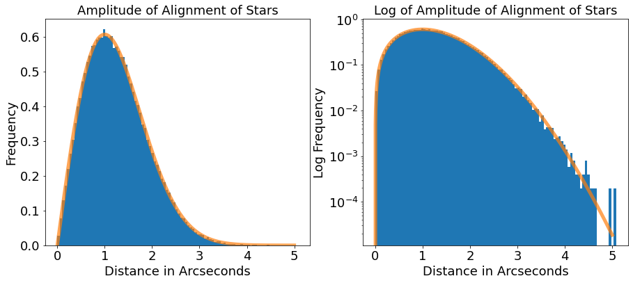

```python
amplitude = np.sqrt(a[0,:]**2 + a[1,:]**2)
fig, ax = plt.subplots(1, 2, figsize=(15, 6))

ax[0].hist(amplitude, bins=100, density=True)
x = np.linspace(0, 5, 1000)
ax[0].plot(x, stats.rayleigh.pdf(x), linewidth = 5, alpha = 0.7)
ax[0].set_title("Amplitude of Alignment of Stars", fontsize=18)
ax[0].set_xlabel("Distance in Arcseconds", fontsize=18)
ax[0].set_ylabel("Frequency", fontsize=18)
plt.tick_params(labelsize = 18)

ax[1].hist(amplitude, bins=100, density=True)
x = np.linspace(0, 5, 1000)
ax[1].plot(x, stats.rayleigh.pdf(x), linewidth = 5, alpha = 0.7)
ax[1].set_title("Log of Amplitude of Alignment of Stars", fontsize=18)
ax[1].set_xlabel("Distance in Arcseconds", fontsize=18)
ax[1].set_ylabel("Log Frequency", fontsize=18)
ax[1].set_yscale('log')
```

#### 3. What distance in arcseconds represents a 5 sigma detection of motion?

```python
# find the probability associated with 5 sigma - under the standard normal, then find the value corresponding to that probability
# on our Rayleigh distribution
prob_5_sigma = abs(stats.norm.cdf(-5))
print("Probability associated with 5 sigma: " + str(prob_5_sigma))
distance = stats.rayleigh.ppf(stats.norm.cdf(5))
print("Distance in arcseconds that represents 5 sigma detection of motion: " + str(distance))
```

```
Probability associated with 5 sigma: 2.866515718791933e-07
Distance in arcseconds that represents 5 sigma detection of motion: 5.489079776034238
```

## Problem 3

As we discussed in class, one of the key backgrounds for gamma-ray telescopes are cosmic rays. Cosmic rays are charged particles—usually protons or electrons but can include atomic nuclei such a alpha particles (helium) or iron. Because of their charge cosmic rays spiral in the magnetic field of the galaxy. From the perspective of the Earth they appear to be coming uniformly from all directions like a high energy gas, and the direction the cosmic ray is travelling when it reaches the Earth tells us nothing about where it came from because we don't know what tortured path it has taken through the galaxy to reach us. However, at trillion electron volt energies and above, the spiral loops are fairly big and the sun and the moon will block cosmic rays. This means the sun and the moon appear as holes in the cosmic ray sky (cosmic rays from that direction are absorbed).

Assume in a moon sized patch on the sky we normally have a cosmic ray rate of 1 cosmic ray per minute (arrivals are random in time). If we can observe where the moon is for 8 hours per night (not too close to the horizon) and we observe for 15 days and see 6800 cosmic rays, what is the signficance of our moon shadow detection?

As always:

#### 1. What is the question in words?

Given that the data of cosmic rays over 15 days at 8 hours per night with 1 cosmic ray per minfollows a Poisson distribution with expected value of 7200, what is the probabilty of getting the value 6800 cosmic rays over this time period?

#### 2. Translate the question to math, describing both the expected background pdf() and the integral you need to do.

The expected background pdf is a Poisson distribution with expected value of 7200. We need to find the probability of exactly 6800 from this background distribution, then do the integral under the standard normal distribution that has this same probability to find the sigma.

#### 3. Convert to sigma.

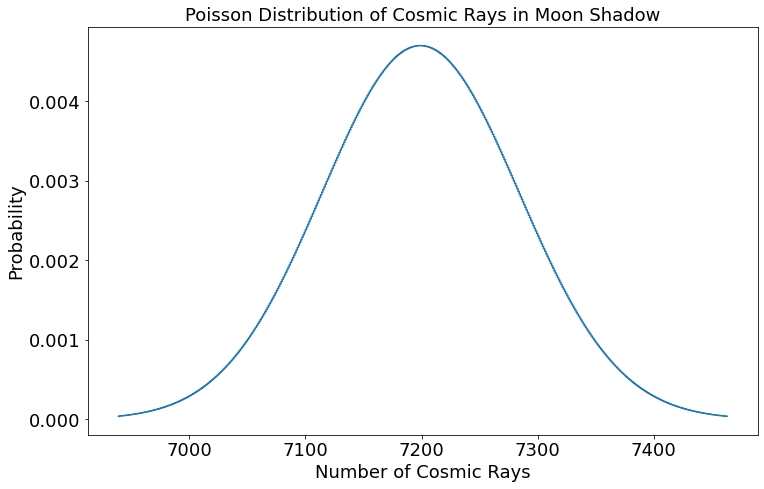

```python
fig, ax = plt.subplots(1, 1)
mu = 7200
x = np.arange(stats.poisson.ppf(0.001, mu), stats.poisson.ppf(0.999, mu))
ax.step(x, stats.poisson.pmf(x, mu))
plt.title("Poisson Distribution of Cosmic Rays in Moon Shadow", fontsize=18)
plt.xlabel("Number of Cosmic Rays", fontsize=18)
plt.ylabel("Probability", fontsize=18)
```

```python
prob_6800 = stats.poisson.pmf(6800, mu)
print("Probability of getting 6800 cosmic rays in a moon-shaped patch of sky over 15 days measuring 8 hours a night: " + str(prob_6800))
sigma_6800 = stats.norm.ppf(prob_6800)
print("The associated sigma value: "+ str(abs(sigma_6800)))
```

```
Probability of getting 6800 cosmic rays in a moon-shaped patch of sky over 15 days measuring 8 hours a night: 5.850956323100652e-08
The associated sigma value: 5.298091812839428
```

#### There are some unique aspects to this problem. Make sure you explore them in your explanation.

Some unique aspects to this problem are that since that data is number of occurences over a certain period of time, the data is a discrete Poisson distribution instead of a continuous one. Since the data follows a Poisson distribution, instead of taking the probabilty of an area, we are only interested in the probability of getting 6800 exactly, and then finding the corresponding area under the standard normal to find the sigma. The sigma also came out negative at first because the probability we got from the Poisson distribution is close to zero, so the absolute value of the negative sigma is the sigma value we want.